# Mendelian Randomization Report

Deciphering the Bidirectional Impact of Leukocyte Telomere Length on Multiple Sclerosis Progression: A Mendelian Randomization Study

Created by Hani Sabaie and Ali Taghavi Rad

2024-10-04

#### Authors List:

1. Hani Sabaie
2. Ali Taghavi Rad
3. Motahareh Shabestari
4. Sahar Seddiq
5. Toktam Saadattalab
6. Danial Habibi
7. Amir Hesam Saeidian
8. Mohadeseh Abbasi
9. Hanifeh Mirtavoos-Mahyari

#### Abbreviations:

- GWAS: Genome-Wide Association Studies
- LTL: Leukocyte Telomere Length
- MR: Mendelian Randomization
- MSP: Multiple Sclerosis Progression
- SNP: Single Nucleotide Polymorphism

# Bidirectional MR Analysis

## LTL on MSP

### Title: Deciphering the Impact of **LTL** on **MSP**

> Introduction
- Exposure: LTL | GWAS summary statistics: [UK Biobank](https://gwas.mrcieu.ac.uk/datasets/ieu-b-4879/) | Reference paper: [Codd et al. 2021](https://www.nature.com/articles/s41588-021-00944-6)
- Sample size: 472,174
- Ancestry: European
- Outcome: MSP | GWAS summary statistics: [International Multiple Sclerosis Genetics Consortium (IMSGC)](https://imsgc.net/?page_id=31) | Reference paper: [Harroud et al. 2023](https://pubmed.ncbi.nlm.nih.gov/37380766/)
- Sample size: 12,584
- Ancestry: European

> Data Prepration
- Number of total SNPs in exposure: 20,134,421 SNPs
- Number of SNPs exposure with p-value < $5\times10^{-8}$: 37,521 SNPs
- Number of SNPs exposure after clumping: 150 SNPs
- Number of total SNPs in outcome: 7,776,916 SNPs
- Number of common variants between exposure and outcome: 138 SNPs
- Number of SNPs after harmonization (action=2): 134 SNPs
- A total of four SNPs (rs2306646, rs56178008, rs611646, rs670180) were removed due to being palindromic.

> Weakness of Instruments

```
##    Min. 1st Qu.  Median    Mean 3rd Qu.    Max.
##   29.86   41.22   60.64  114.57  106.58 1105.85
```

The number of SNPs eliminated through the process of checking for weakness: 0 SNP

> Initial MR

```
##   id.exposure id.outcome outcome exposure                    method nsnp
## 1      RX8hD3     YXaXU2 outcome exposure                  MR Egger  134
## 2      RX8hD3     YXaXU2 outcome exposure           Weighted median  134
## 3      RX8hD3     YXaXU2 outcome exposure Inverse variance weighted  134
## 4      RX8hD3     YXaXU2 outcome exposure               Simple mode  134
## 5      RX8hD3     YXaXU2 outcome exposure             Weighted mode  134
##            b         se       pval
## 1 0.17407936 0.09337643 0.06450420
## 2 0.15164728 0.07973032 0.05717079
## 3 0.07501956 0.05101686 0.14143029
## 4 0.02420997 0.17578912 0.89066867
## 5 0.13661292 0.09052598 0.13364474
```

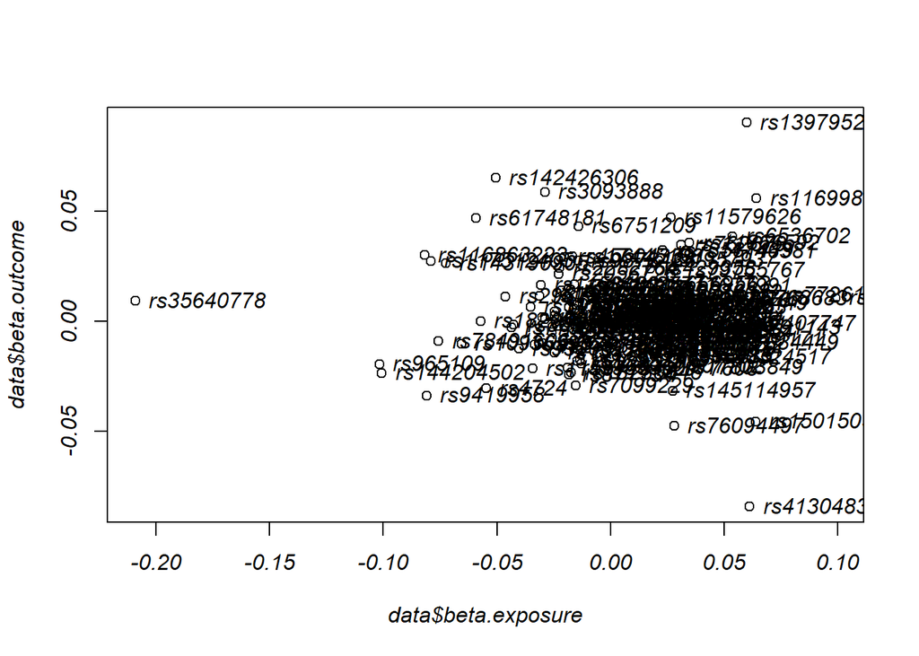

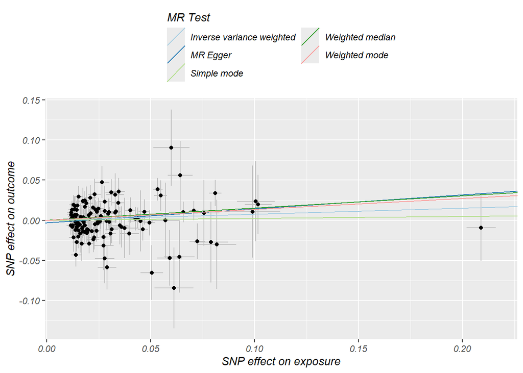

```
##   id.exposure id.outcome outcome exposure                    method        Q
## 1      RX8hD3     YXaXU2 outcome exposure                  MR Egger 154.4203
## 2      RX8hD3     YXaXU2 outcome exposure Inverse variance weighted 156.2935
##   Q_df     Q_pval
## 1  132 0.08864073
## 2  133 0.08184527
```

```
##   id.exposure id.outcome outcome exposure egger_intercept          se      pval
## 1      RX8hD3     YXaXU2 outcome exposure    -0.003204502 0.002532373 0.2079519
```

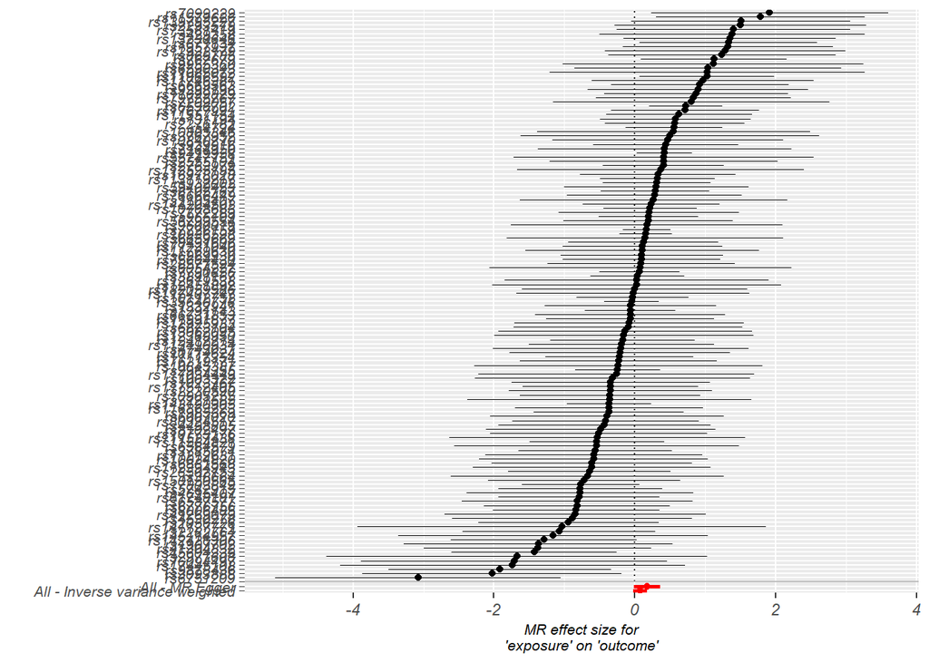

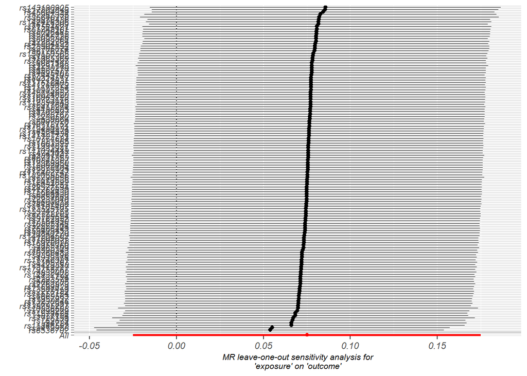

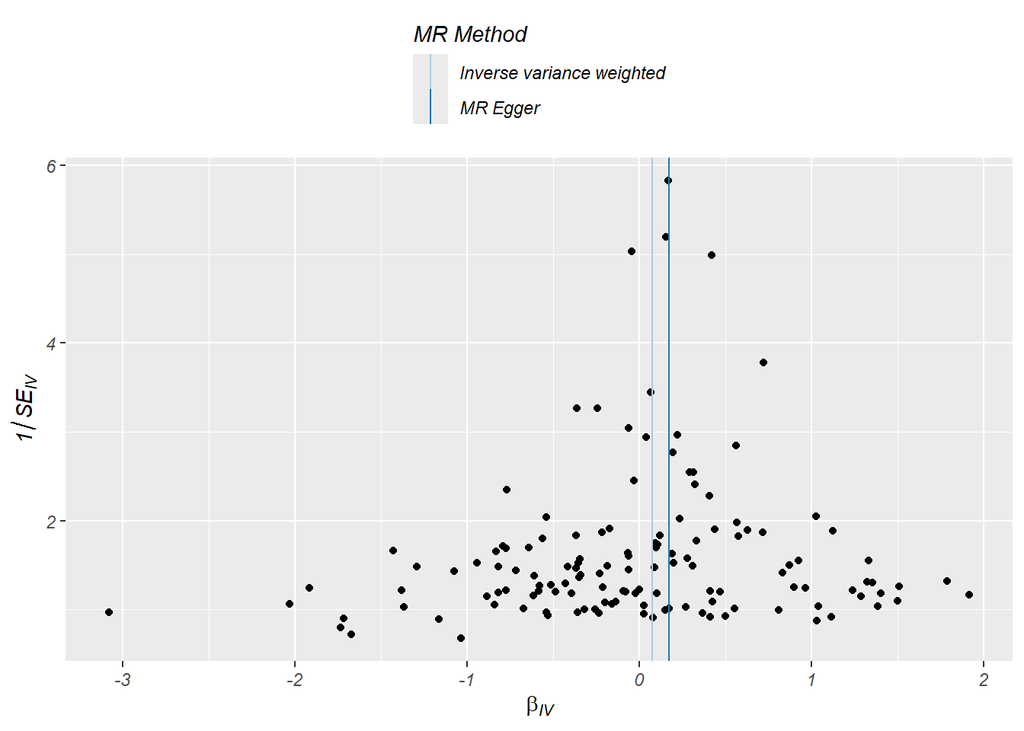

> MR-PRESSO Test

```
## $`Main MR results`
##        Exposure       MR Analysis Causal Estimate         Sd   T-stat   P-value
## 1 beta.exposure               Raw      0.07501956 0.05101686 1.470486 0.1437921
## 2 beta.exposure Outlier-corrected              NA         NA       NA        NA
##
## $`MR-PRESSO results`
## $`MR-PRESSO results`$`Global Test`
## $`MR-PRESSO results`$`Global Test`$RSSobs
## [1] 158.7034
##
## $`MR-PRESSO results`$`Global Test`$Pvalue
## [1] 0.079
```

> RadialMR Test

```
##
## Radial IVW
##
##                    Estimate  Std.Error  t value  Pr(>|t|)
## Effect (Mod.2nd) 0.07501860 0.05101696 1.470464 0.1414362
## Iterative        0.07501860 0.05101696 1.470464 0.1414362
## Exact (FE)       0.07578144 0.04706587 1.610115 0.1073728
## Exact (RE)       0.07564507 0.05397434 1.401501 0.1633937
##
##
## Residual standard error: 1.084 on 133 degrees of freedom
##
## F-statistic: 2.16 on 1 and 133 DF, p-value: 0.144
## Q-Statistic for heterogeneity: 156.2681 on 133 DF , p-value: 0.0820576
##
##  No significant outliers
## Number of iterations = 2
```

```
## [1] "No significant outliers"
```

> Standardized Residuals

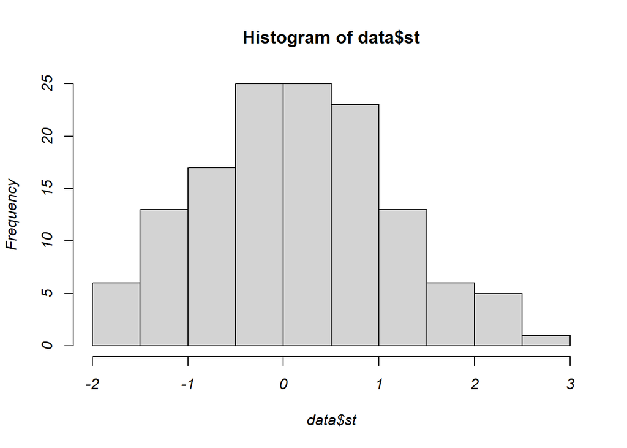

```
## integer(0)
```

> Cook’s Distance

“In statistics, Cook’s distance or Cook’s D is a commonly used estimate of the influence of a data point when performing a least-squares regression analysis. In a practical ordinary least squares analysis, Cook’s distance can be used in several ways: to indicate influential data points that are particularly worth checking for validity; or to indicate regions of the design space where it would be good to be able to obtain more data points. It is named after the American statistician R. Dennis Cook, who introduced the concept in 1977” ([Refernce](https://en.wikipedia.org/wiki/Cook%27s_distance)).

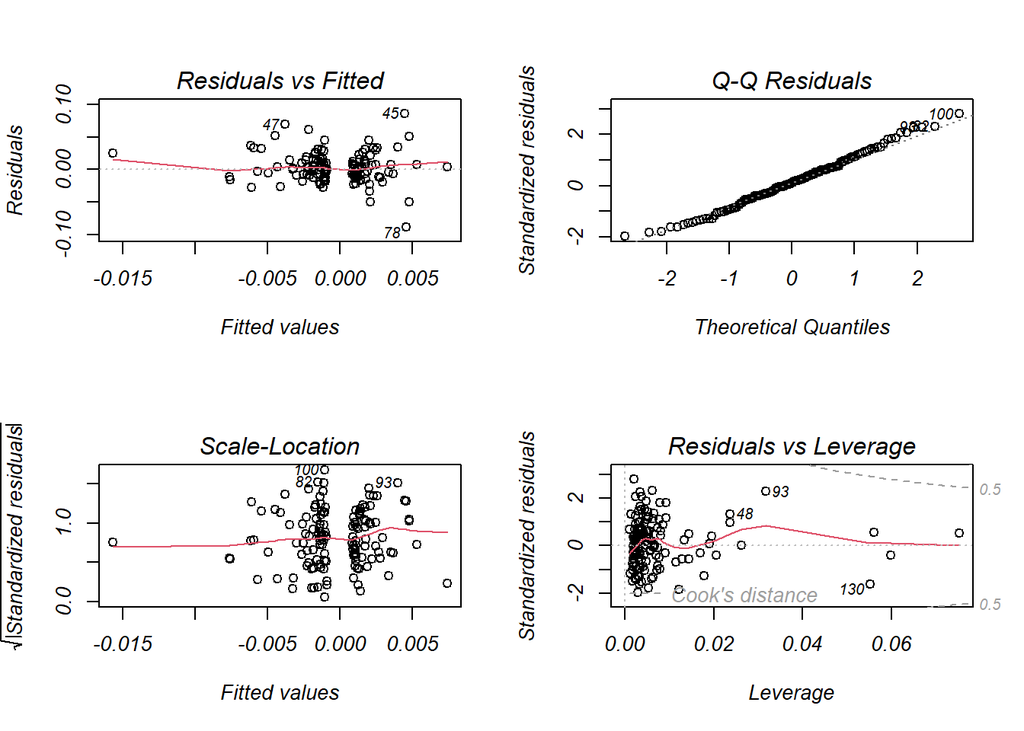

> Potential Outliers and Influential SNPs

```
## rs139795227 rs142426306 rs143190905 rs41304832 rs45604339 rs6536702 rs6751209 rs9419958 rs17803849 rs9878436 rs61748181 rs11584821 rs8006485
```

> MR Analysis After Deleting Outliers and Influential SNPs

```
##   id.exposure id.outcome outcome exposure                    method nsnp
## 1      RX8hD3     YXaXU2 outcome exposure                  MR Egger  121
## 2      RX8hD3     YXaXU2 outcome exposure           Weighted median  121
## 3      RX8hD3     YXaXU2 outcome exposure Inverse variance weighted  121
## 4      RX8hD3     YXaXU2 outcome exposure               Simple mode  121
## 5      RX8hD3     YXaXU2 outcome exposure             Weighted mode  121
##            b         se       pval
## 1 0.12519867 0.09680580 0.19841324
## 2 0.14998274 0.08122434 0.06481606
## 3 0.10748784 0.05158760 0.03719672
## 4 0.04011594 0.15860054 0.80074969
## 5 0.11085936 0.09164646 0.22879414
```

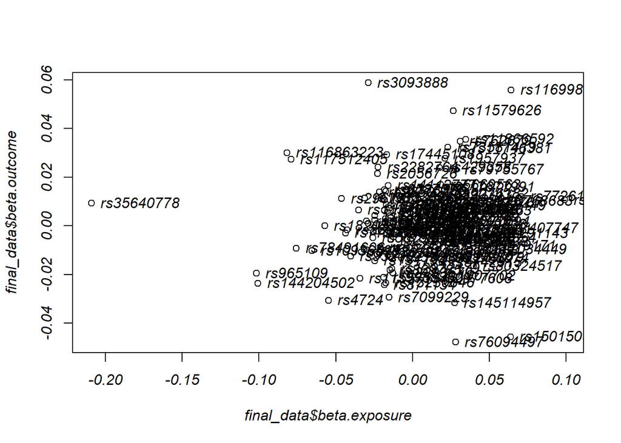

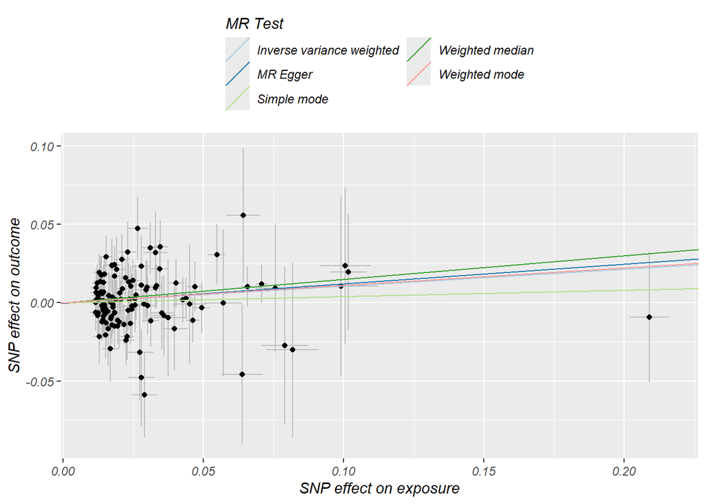

```
##   id.exposure id.outcome outcome exposure                    method        Q
## 1      RX8hD3     YXaXU2 outcome exposure                  MR Egger 102.7374
## 2      RX8hD3     YXaXU2 outcome exposure Inverse variance weighted 102.7841
##   Q_df    Q_pval
## 1  119 0.8560318
## 2  120 0.8698709
```

```
##   id.exposure id.outcome outcome exposure egger_intercept          se      pval
## 1      RX8hD3     YXaXU2 outcome exposure   -0.0005410524 0.002502444 0.8291946
```

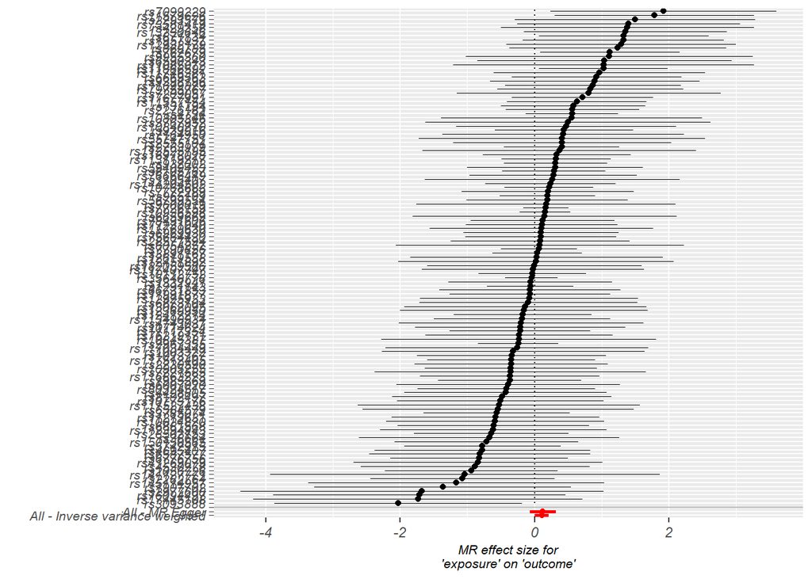

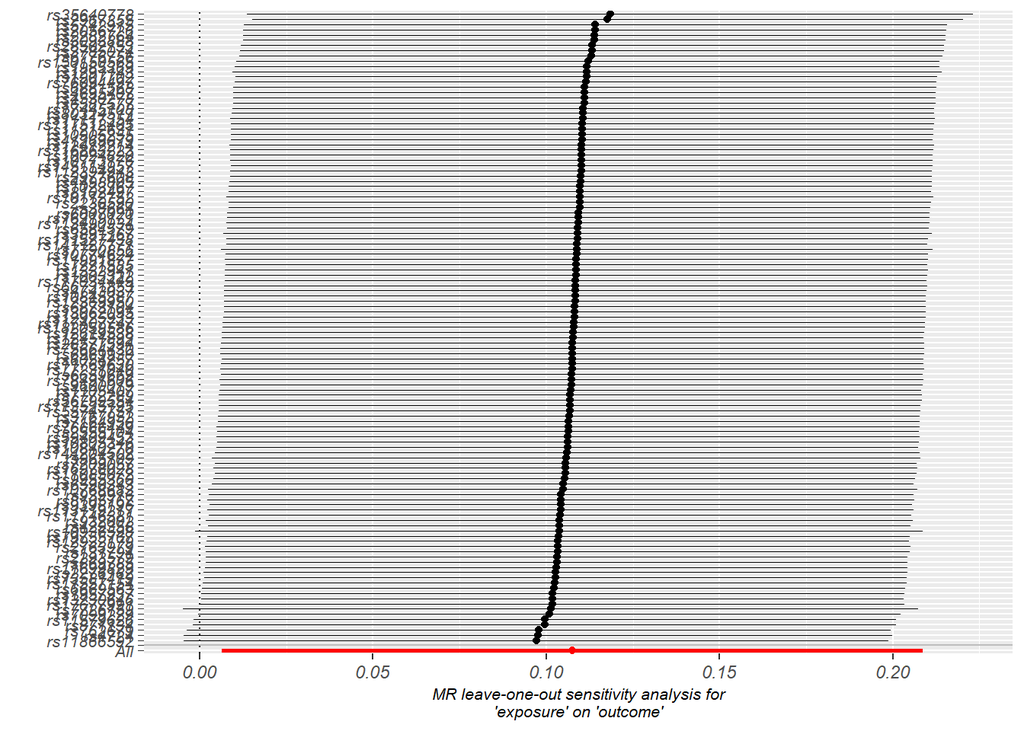

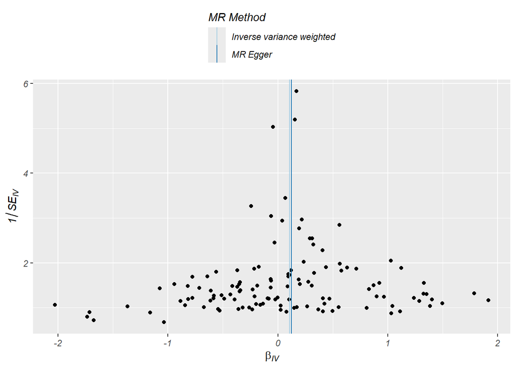

> Sensitivity Analyses With MendelianRandomization Package

```
##
## Inverse-variance weighted method
## (variants uncorrelated, random-effect model)
##
## Number of Variants : 121
##
## ------------------------------------------------------------------
##  Method Estimate Std Error 95% CI       p-value
##     IVW    0.107     0.052 0.006, 0.209   0.037
## ------------------------------------------------------------------
## Residual standard error =  0.925
## Residual standard error is set to 1 in calculation of confidence interval when its estimate is less than 1.
## Heterogeneity test statistic (Cochran's Q) = 102.7841 on 120 degrees of freedom, (p-value = 0.8699). I^2 = 0.0%.
## F statistic = 106.2.
```

```
##                     Method Estimate Std Error 95% CI        P-value
##              Simple median    0.027     0.081  -0.133 0.186   0.742
##            Weighted median    0.150     0.081  -0.009 0.309   0.064
##  Penalized weighted median    0.150     0.081  -0.009 0.309   0.065
##
##                        IVW    0.107     0.052   0.006 0.209   0.037
##              Penalized IVW    0.107     0.052   0.006 0.209   0.037
##                 Robust IVW    0.097     0.045   0.009 0.185   0.030
##       Penalized robust IVW    0.097     0.045   0.009 0.185   0.030
##
##                   MR-Egger    0.125     0.097  -0.065 0.315   0.196
##                (intercept)   -0.001     0.003  -0.005 0.004   0.829
##         Penalized MR-Egger    0.125     0.097  -0.065 0.315   0.196
##                (intercept)   -0.001     0.003  -0.005 0.004   0.829
##            Robust MR-Egger    0.129     0.073  -0.013 0.272   0.075
##                (intercept)   -0.001     0.002  -0.006 0.003   0.648
##  Penalized robust MR-Egger    0.129     0.073  -0.013 0.272   0.075
##                (intercept)   -0.001     0.002  -0.006 0.003   0.648
```

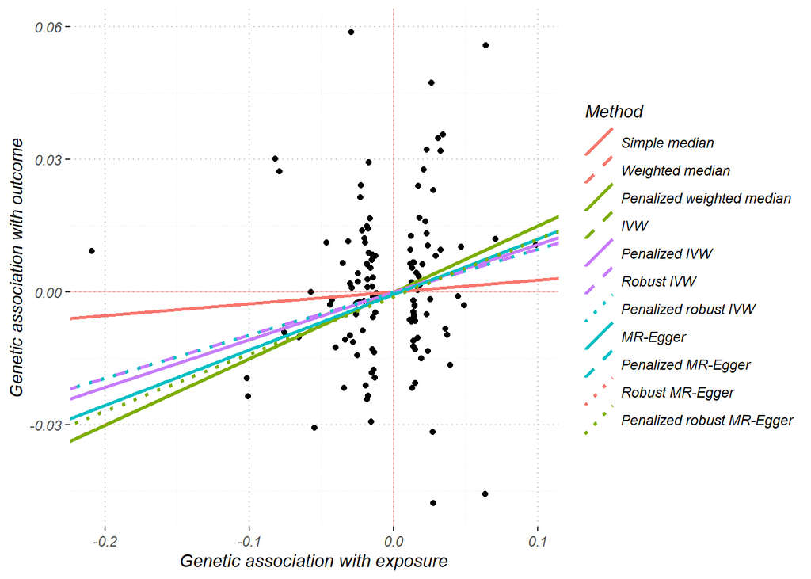

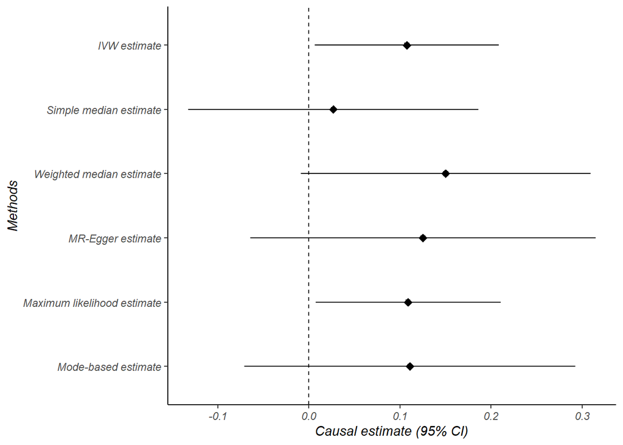

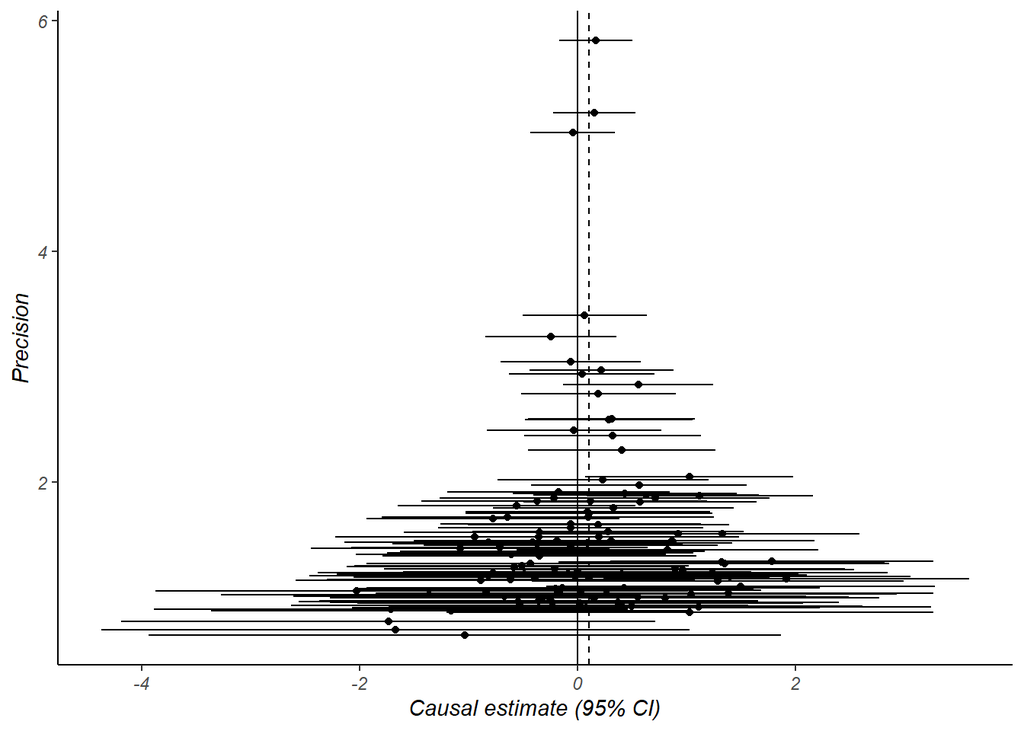

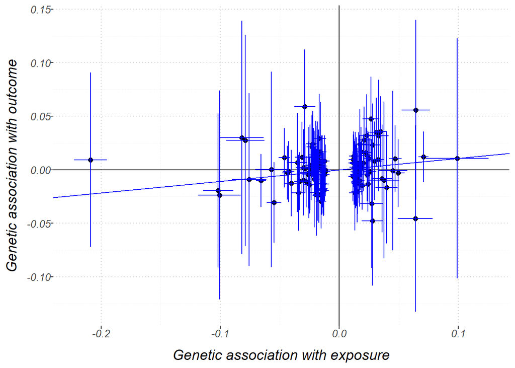

> MR Steiger Test of Directionality

| id.exposure | id.outcome | exposure | outcome | snp_r2.exposure | snp_r2.outcome | correct_causal_direction | steiger_pval |
| --- | --- | --- | --- | --- | --- | --- | --- |
| RX8hD3 | YXaXU2 | exposure | outcome | 0.026743 | 0.0085137 | TRUE | 0 |

```
## $r2_exp
## [1] 0
##
## $r2_out
## [1] 0.25
##
## $r2_exp_adj
## [1] 0
##
## $r2_out_adj
## [1] 0.25
##
## $correct_causal_direction
## [1] FALSE
##
## $steiger_test
## [1] 0
##
## $correct_causal_direction_adj
## [1] FALSE
##
## $steiger_test_adj
## [1] 0
##
## $vz
## [1] NaN
##
## $vz0
## [1] 0
##
## $vz1
## [1] NaN
##
## $sensitivity_ratio
## [1] NaN
##
## $sensitivity_plot
```

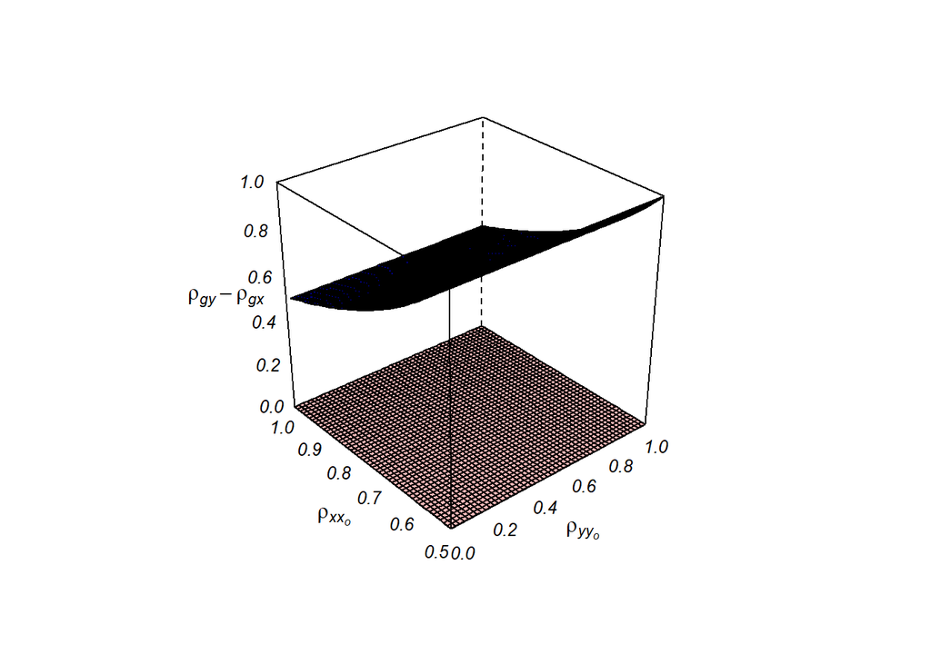

> Other MR Methods

```
## MR-RAPS method
```

```
## $beta.hat
## [1] 0.1083275
##
## $beta.se
## [1] 0.05212262
##
## $beta.p.value
## [1] 0.03767981
##
## $naive.se
## [1] 0.05187878
##
## $chi.sq.test
## [1] 102.7501
```

```
##   over.dispersion loss.function   beta.hat    beta.se
## 1           FALSE            l2 0.10832753 0.05212262
## 2           FALSE         huber 0.09786823 0.05347324
## 3           FALSE         tukey 0.09887664 0.05347365
## 4            TRUE            l2 0.10832672 0.05212399
## 5            TRUE         huber 0.09786823 0.05347339
## 6            TRUE         tukey 0.09887662 0.05347381
```

```
##
## MR-Lasso method
##
## Number of variants : 121
## Number of valid instruments : 121
## Tuning parameter : 0.2068065
## ------------------------------------------------------------------
##  Exposure Estimate Std Error 95% CI       p-value
##  exposure    0.107     0.052 0.006, 0.209   0.037
## ------------------------------------------------------------------
```

```
##
## Constrained maximum likelihood method (MRcML)
## Number of Variants:  121
## Results for:  cML-MA-BIC
## ------------------------------------------------------------------
##      Method Estimate    SE Pvalue        95% CI
##  cML-MA-BIC    0.109 0.052  0.036 [0.007,0.211]
## ------------------------------------------------------------------
```

```
##
## Debiased inverse-variance weighted method
## (Over.dispersion:TRUE)
##
## Number of Variants : 121
## ------------------------------------------------------------------
##  Method Estimate Std Error 95% CI       p-value Condition
##    dIVW    0.108     0.052 0.006, 0.211   0.037  1157.055
## ------------------------------------------------------------------
```

```
##
## Mode-based method of Hartwig et al
## (weighted, delta standard errors [not assuming NOME], bandwidth factor = 1)
##
## Number of Variants : 121
## ------------------------------------------------------------------
##  Method Estimate Std Error  95% CI       p-value
##     MBE    0.111     0.094 -0.073, 0.295   0.238
## ------------------------------------------------------------------
```

## MSP on LTL

### Title: Deciphering the Impact of **MSP** on **LTL**

> Introduction
- Exposure: MSP | GWAS summary statistics: [International Multiple Sclerosis Genetics Consortium (IMSGC)](https://imsgc.net/?page_id=31) | Reference paper: [Harroud et al. 2023](https://pubmed.ncbi.nlm.nih.gov/37380766/)
- Sample size: 12,584
- Ancestry: European
- Outcome: LTL | GWAS summary statistics: [UK Biobank](https://gwas.mrcieu.ac.uk/datasets/ieu-b-4879/) | Reference paper: [Codd et al. 2021](https://www.nature.com/articles/s41588-021-00944-6)
- Sample size: 472,174
- Ancestry: European

> Data Prepration
- Number of total SNPs in exposure: 7,776,916 SNPs
- Number of SNPs exposure with p-value < $5\times10^{-5}$: 356 SNPs
- Number of SNPs exposure after clumping: 87 SNPs
- Number of total SNPs in outcome: 20,134,421 SNPs
- Number of common variants between exposure and outcome: 78 SNPs
- Number of SNPs after harmonization (action=2): 78 SNPs

> Weakness of Instruments

```
##    Min. 1st Qu.  Median    Mean 3rd Qu.    Max.
##   16.51   17.26   18.26   18.95   19.78   32.90
```

The number of SNPs eliminated through the process of checking for weakness: 0 SNP

> Initial MR

```
##   id.exposure id.outcome outcome exposure                    method nsnp
## 1      nURK4f     FheClD outcome exposure                  MR Egger   78
## 2      nURK4f     FheClD outcome exposure           Weighted median   78
## 3      nURK4f     FheClD outcome exposure Inverse variance weighted   78
## 4      nURK4f     FheClD outcome exposure               Simple mode   78
## 5      nURK4f     FheClD outcome exposure             Weighted mode   78
##               b          se      pval
## 1  0.0032548295 0.010215094 0.7508815
## 2 -0.0009435078 0.006504165 0.8846618
## 3  0.0018844096 0.004716133 0.6894757
## 4 -0.0132432167 0.017443670 0.4500515
## 5 -0.0070434241 0.016440723 0.6695463
```

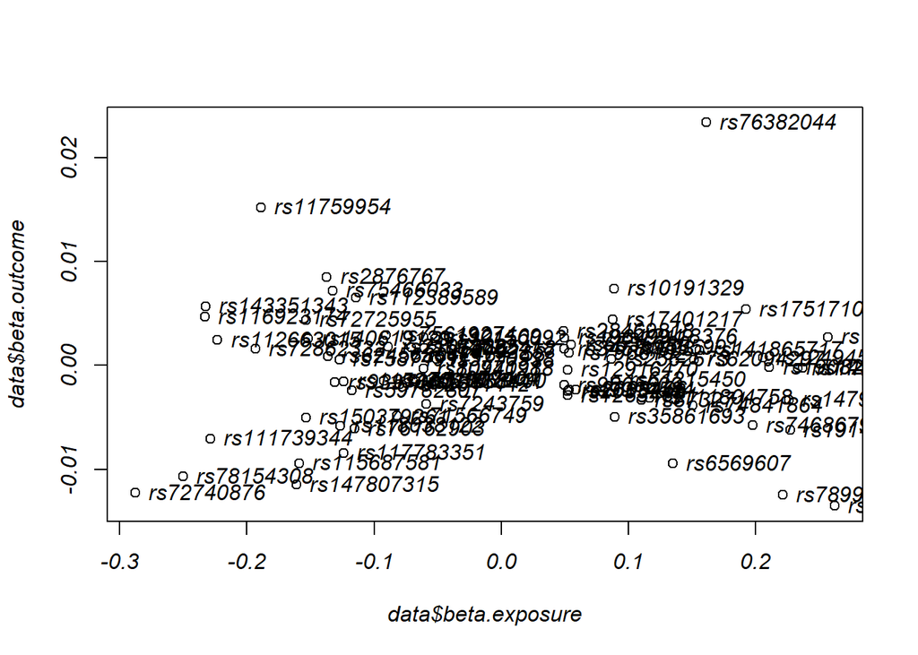

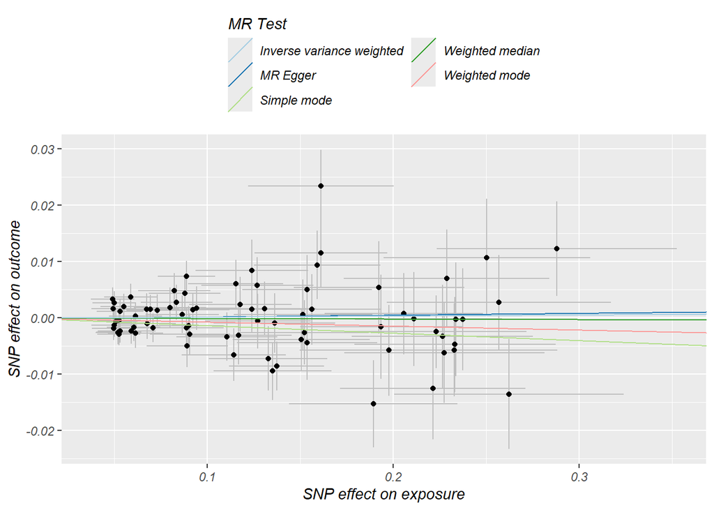

```
##   id.exposure id.outcome outcome exposure                    method        Q
## 1      nURK4f     FheClD outcome exposure                  MR Egger 89.69824
## 2      nURK4f     FheClD outcome exposure Inverse variance weighted 89.72533
##   Q_df    Q_pval
## 1   76 0.1348173
## 2   77 0.1522365
```

```
##   id.exposure id.outcome outcome exposure egger_intercept           se
## 1      nURK4f     FheClD outcome exposure   -0.0001344673 0.0008875522
##        pval
## 1 0.8799799
```

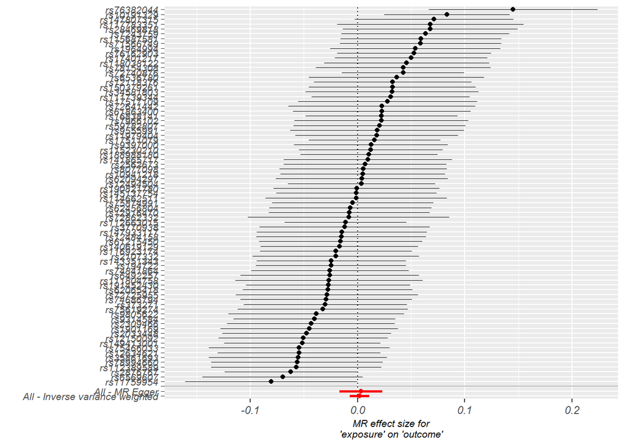

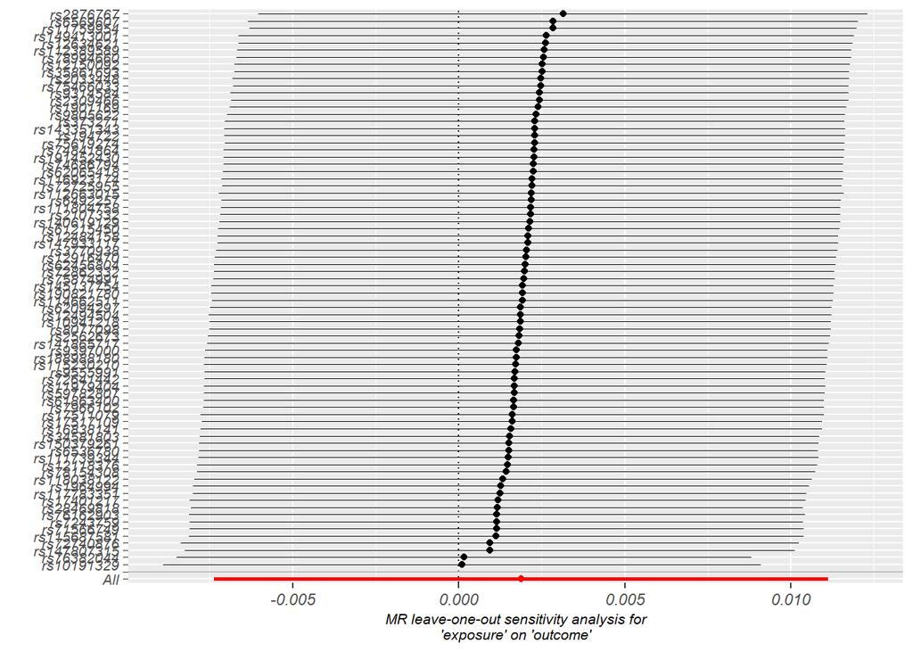

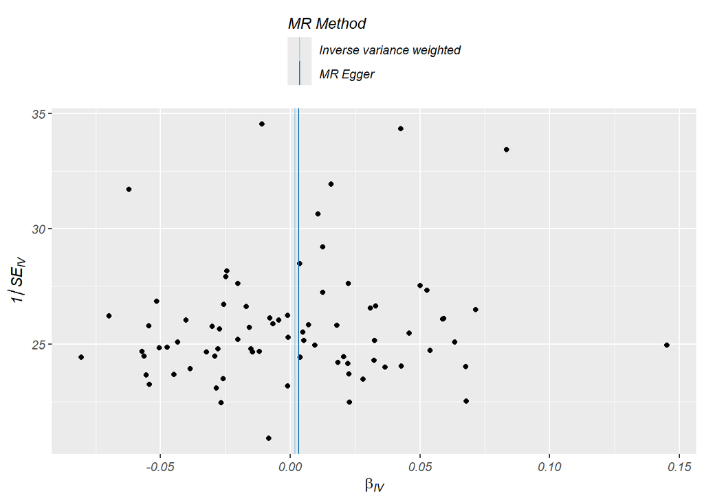

> MR-PRESSO Test

```
## $`Main MR results`
##        Exposure       MR Analysis Causal Estimate          Sd    T-stat
## 1 beta.exposure               Raw      0.00188441 0.004716133 0.3995667
## 2 beta.exposure Outlier-corrected              NA          NA        NA
##     P-value
## 1 0.6905819
## 2        NA
##
## $`MR-PRESSO results`
## $`MR-PRESSO results`$`Global Test`
## $`MR-PRESSO results`$`Global Test`$RSSobs
## [1] 92.19636
##
## $`MR-PRESSO results`$`Global Test`$Pvalue
## [1] 0.1522
```

> RadialMR Test

```
##
## Radial IVW
##
##                     Estimate   Std.Error   t value  Pr(>|t|)
## Effect (Mod.2nd) 0.001884333 0.004716140 0.3995499 0.6894881
## Iterative        0.001884333 0.004716140 0.3995499 0.6894881
## Exact (FE)       0.002005036 0.004369238 0.4588984 0.6463071
## Exact (RE)       0.001992727 0.005061423 0.3937089 0.6948841
##
##
## Residual standard error: 1.079 on 77 degrees of freedom
##
## F-statistic: 0.16 on 1 and 77 DF, p-value: 0.691
## Q-Statistic for heterogeneity: 89.71399 on 77 DF , p-value: 0.1524308
##
##  Outliers detected
## Number of iterations = 2
```

```
##          SNP Q_statistic      p.value
## 1 rs76382044     12.7873 0.0003489804
```

> Standardized Residuals

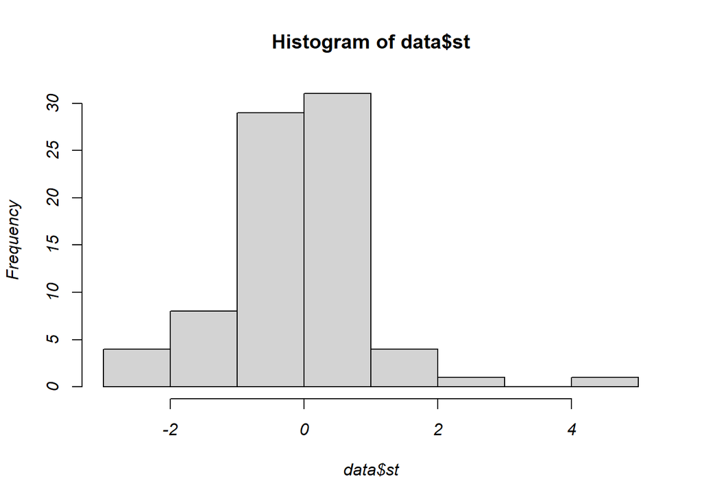

```
## [1] 70
```

> Cook’s Distance

“In statistics, Cook’s distance or Cook’s D is a commonly used estimate of the influence of a data point when performing a least-squares regression analysis. In a practical ordinary least squares analysis, Cook’s distance can be used in several ways: to indicate influential data points that are particularly worth checking for validity; or to indicate regions of the design space where it would be good to be able to obtain more data points. It is named after the American statistician R. Dennis Cook, who introduced the concept in 1977” ([Refernce](https://en.wikipedia.org/wiki/Cook%27s_distance)).

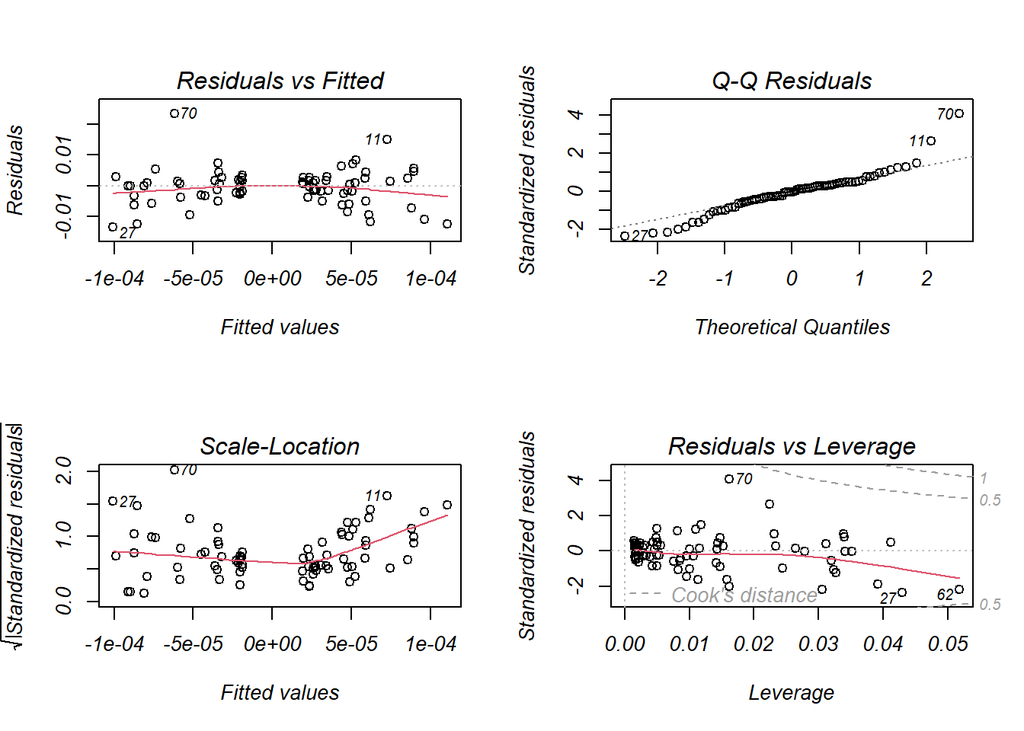

> Potential Outliers and Influential SNPs

```
## rs76382044 rs11759954 rs149413001 rs72740876 rs10191329 rs147807315 rs115687581 rs71566749 rs7243759 rs76162903 rs28469818 rs17401217 rs117783351 rs118038122 rs78154308
```

> MR Analysis After Deleting Outliers and Influential SNPs

```
##   id.exposure id.outcome outcome exposure                    method nsnp
## 1      nURK4f     FheClD outcome exposure                  MR Egger   63
## 2      nURK4f     FheClD outcome exposure           Weighted median   63
## 3      nURK4f     FheClD outcome exposure Inverse variance weighted   63
## 4      nURK4f     FheClD outcome exposure               Simple mode   63
## 5      nURK4f     FheClD outcome exposure             Weighted mode   63
##              b          se       pval
## 1 -0.010356970 0.010710819 0.33738056
## 2 -0.008930759 0.006785595 0.18812872
## 3 -0.010222232 0.004900368 0.03697743
## 4 -0.018740708 0.015374316 0.22747616
## 5 -0.016101339 0.016170798 0.32326393
```

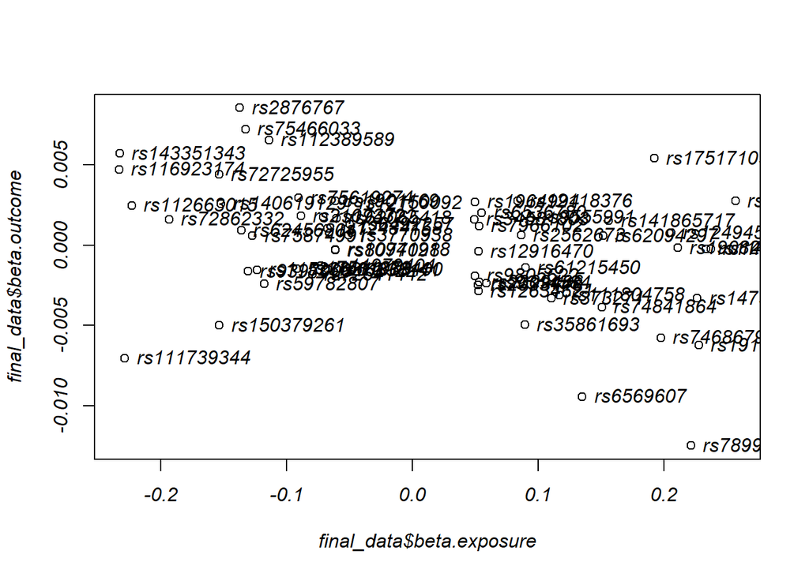

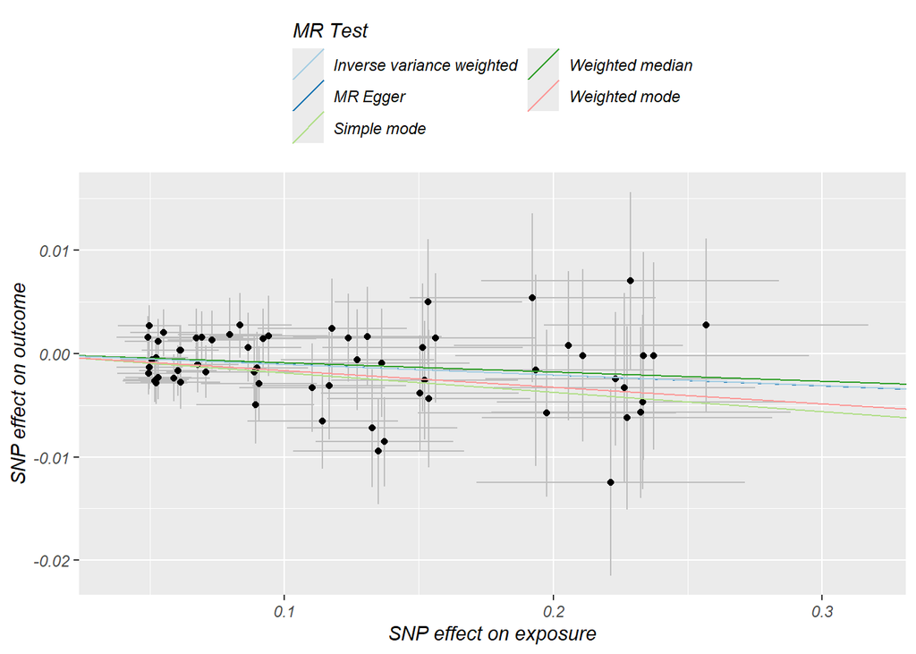

```
##   id.exposure id.outcome outcome exposure                    method        Q
## 1      nURK4f     FheClD outcome exposure                  MR Egger 34.48608
## 2      nURK4f     FheClD outcome exposure Inverse variance weighted 34.48628
##   Q_df    Q_pval
## 1   61 0.9975517
## 2   62 0.9982103
```

```
##   id.exposure id.outcome outcome exposure egger_intercept           se
## 1      nURK4f     FheClD outcome exposure    1.270949e-05 0.0008983854
##        pval
## 1 0.9887588
```

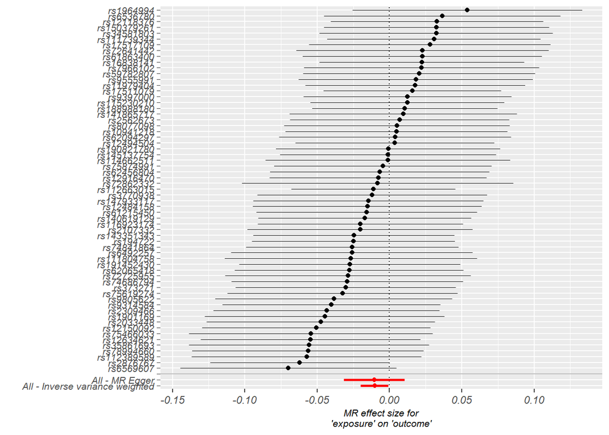

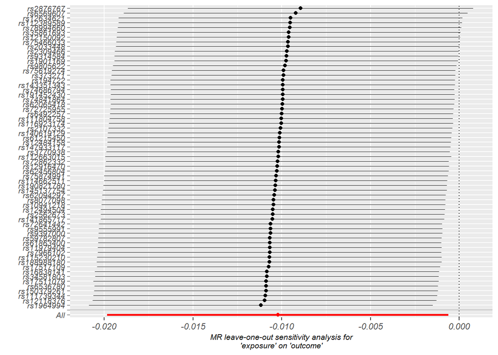

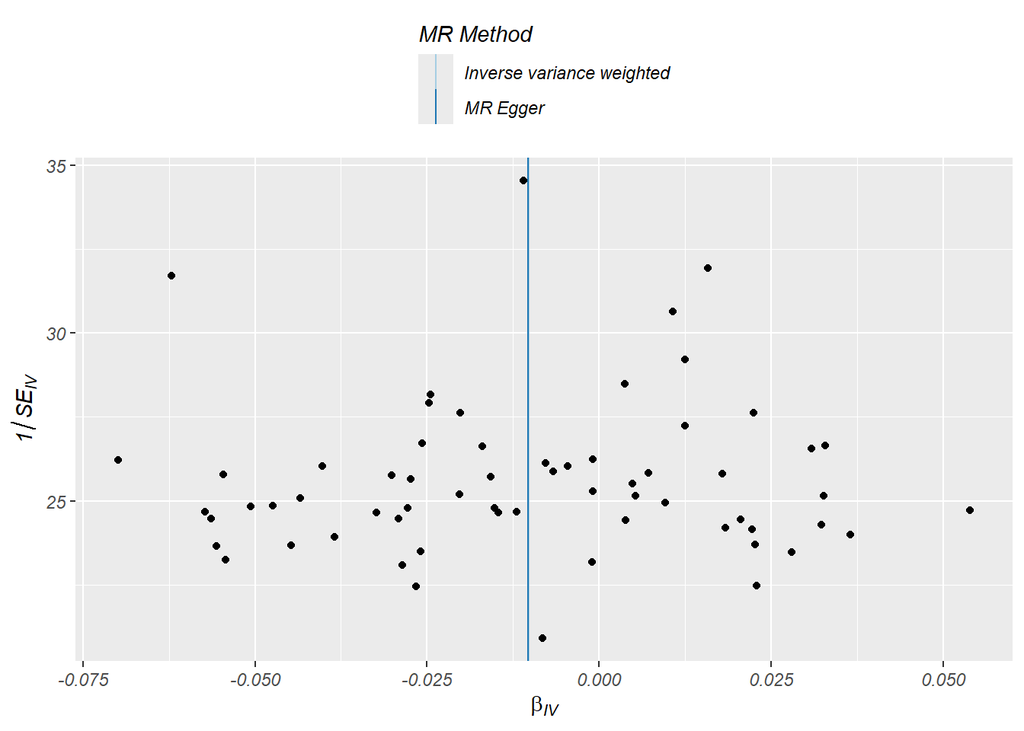

> Sensitivity Analyses With MendelianRandomization Package

```
##
## Inverse-variance weighted method
## (variants uncorrelated, random-effect model)
##
## Number of Variants : 63
##
## ------------------------------------------------------------------
##  Method Estimate Std Error  95% CI        p-value
##     IVW   -0.010     0.005 -0.020, -0.001   0.037
## ------------------------------------------------------------------
## Residual standard error =  0.746
## Residual standard error is set to 1 in calculation of confidence interval when its estimate is less than 1.
## Heterogeneity test statistic (Cochran's Q) = 34.4863 on 62 degrees of freedom, (p-value = 0.9982). I^2 = 0.0%.
## F statistic = 18.8.
```

```
##                     Method Estimate Std Error 95% CI         P-value
##              Simple median   -0.011     0.007  -0.024  0.002   0.103
##            Weighted median   -0.010     0.007  -0.023  0.003   0.133
##  Penalized weighted median   -0.010     0.007  -0.023  0.003   0.133
##
##                        IVW   -0.010     0.005  -0.020 -0.001   0.037
##              Penalized IVW   -0.010     0.005  -0.020 -0.001   0.037
##                 Robust IVW   -0.010     0.005  -0.019 -0.001   0.031
##       Penalized robust IVW   -0.010     0.005  -0.019 -0.001   0.031
##
##                   MR-Egger   -0.010     0.011  -0.031  0.011   0.334
##                (intercept)    0.000     0.001  -0.002  0.002   0.989
##         Penalized MR-Egger   -0.010     0.011  -0.031  0.011   0.334
##                (intercept)    0.000     0.001  -0.002  0.002   0.989
##            Robust MR-Egger   -0.008     0.010  -0.027  0.010   0.385
##                (intercept)    0.000     0.001  -0.002  0.002   0.878
##  Penalized robust MR-Egger   -0.008     0.010  -0.027  0.010   0.385
##                (intercept)    0.000     0.001  -0.002  0.002   0.878
```

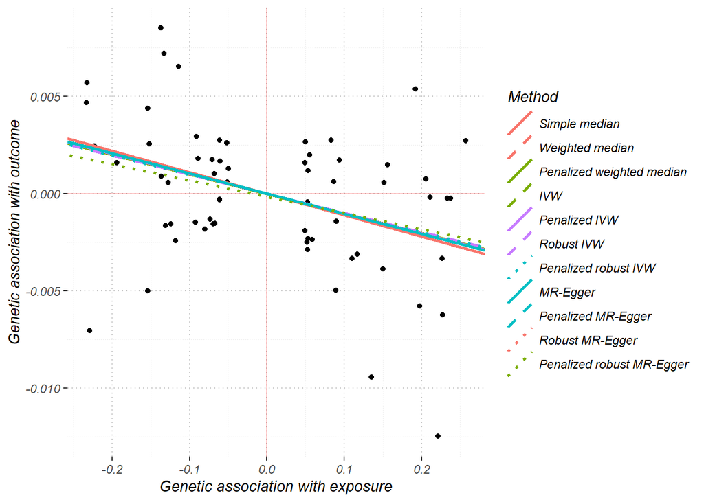

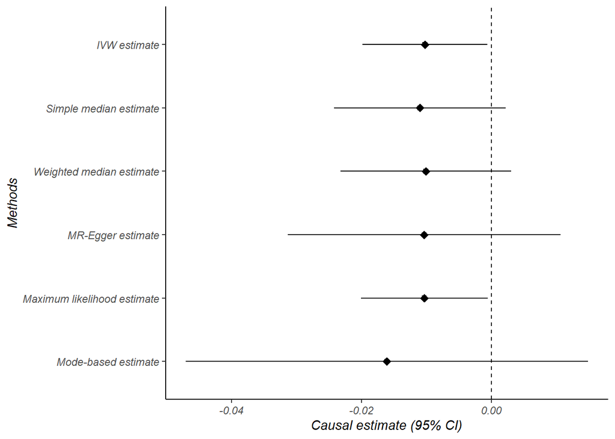